# Jordan covid -19 pandemic overview

GVDN Jayathialke - AS2019402

2022-10-07

## 1.Brief Introduction to country Jordan

small Arab country located in the Middle East. The desert rocky plateau, which occupies most of its territory, rises 700-1000 meters above sea level, it is cut by gorges and rivers. The southern part of Jordan is occupied by the Syrian Desert, wooded uplands are located in the north, and flat basalt deserts are in the east. The state borders on Israel, Saudi Arabia, Syria and Iraq. In recent centuries, strong earthquakes have not been observed in the country, but in general this is a zone of increased seismic activity. A short section of Jordan’s border runs along the Red Sea, and there are year-round resorts - the water temperature does not drop below 24 degrees.

### 1.1 Visualization of the location on world map

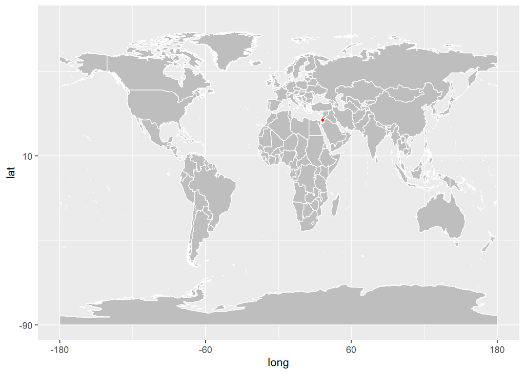

```r
library(ggplot2)
library(maptools)
library(tibble)
library(tidyverse)
library(ggrepel)
library(png)
library(grid)
library(sp)
library(coronavirus)
library(magrittr)
jordan_corona<-coronavirus%>%filter(country=="Jordan")

data("wrld_simpl")
p <-ggplot()+
  geom_polygon(
    data = wrld_simpl,
    aes(x=long ,y=lat ,group=group) ,fill="gray",color="white"
    )+
  coord_cartesian(xlim = c(-180,180),ylim = c(-90,90))+
  scale_x_continuous(breaks = seq(-180,180,120))+
  scale_y_continuous(breaks = seq(-90,90,100))
 p+
   geom_point(
   data = jordan_corona, aes(x=long, y=lat), color="red", size
   =1
   )
```

### Lockdown Status

Jordan’s National Epidemics Committee and Health Ministry designated certain hospitals to treat infections and established several protocols to deal with the arrival of the coronavirus. The country recorded its first case on 2 March, but only had one confirmed case on 14 March. On 15 March, the government implemented a plan to quarantine arrivals before the borders and the airport were closed.A coronavirus infected patient had attended a wedding with 400 guests in Irbid. The government announced a lockdown on 17 March, which was later turned into a strictly-enforced curfew. Civil defense sirens were used to announce the end of when people can go out.